# United States Storm Data Analysis on Health and Economic Impact

YeongWei

Sunday, October 11, 2015

# Synopsis

The dataset is studied and parsed to retain the relevant columns. It is then further enriched for the purpose of computation and analysis. On date/time aspects, *time zones* and *end date/time* are discarded, only retains the *begin date/time*. Based on this [link](https://d396qusza40orc.cloudfront.net/repdata%2Fpeer2_doc%2Fpd01016005curr.pdf), *FATALITIES* and *INJURIES* are treated as the number of cases recorded. On *PROPDMGEXP* and *CROPDMGEXP*, only rows with magnitude represented by the alphabetical characters “K”, “M” and “B” is retained, where K represents Thousand, M as Million and B as Billion. The actual *PROPDMGVAL* and *CROPDMGVAL* values are computed by multiplying the integers with the magnitudes described. The total of *FATALITIES* and *INJURIES* is the metric used to measure health impact. The total of *PROPDMGVAL* and *CROPDMGVAL* actual values is the metric used to mesaure economic impact. *TORNADO* has highest impact on health. *Flood* contributed has highest impact on economy.

# Data Processing

## Reading Data

1. It is assumed that the Storm Data CSV is named as ‘repdata-data-StormData.csv’ and placed in the current working directory.

```r
stormDataCsv <- "repdata-data-StormData.csv"
stormDataCsvFullpath <- paste(workingDir, "\\", stormDataCsv, sep = "")
STORM_DATA <- read.csv(file = stormDataCsvFullpath, header = TRUE);
```

## Discard Irrelevant Columns

```r
interestedColumns <- c(
  "BGN_DATE", "STATE", "COUNTYNAME", "EVTYPE",
  "FATALITIES", "INJURIES", "PROPDMG", "PROPDMGEXP", "CROPDMG", "CROPDMGEXP");
STORM_DATA <- STORM_DATA[, interestedColumns];
```

## Parse Date/Time

```r
dateTimeFormat <- "%m/%d/%Y";
STORM_DATA$BGN_DATE <- strptime(STORM_DATA$BGN_DATE, format = dateTimeFormat);
STORM_DATA <- STORM_DATA[!is.na(STORM_DATA$BGN_DATE), ];
```

## Promote Magnitude “m” to “M”

```r
STORM_DATA[STORM_DATA$PROPDMGEXP == "m", ]$PROPDMGEXP <- "M"
STORM_DATA[STORM_DATA$CROPDMGEXP == "m", ]$CROPDMGEXP <- "M"
```

## Subset Rows for only Magnitude B, M abd K

```r
relevantUnits <- c("K", "M", "B");
STORM_DATA <- STORM_DATA[
  STORM_DATA$PROPDMGEXP %in% relevantUnits & STORM_DATA$CROPDMGEXP %in% relevantUnits, ];

STORM_DATA$PROPDMGEXP <- as.character(STORM_DATA$PROPDMGEXP);
STORM_DATA$CROPDMGEXP <- as.character(STORM_DATA$CROPDMGEXP);
```

## Compute Damage(*DMG) Actual Values

```r
unitValues <- list();
unitValues[["K"]] <- 1000;
unitValues[["M"]] <- 1000000;
unitValues[["B"]] <- 1000000000;

PROPDMGVAL <- mapply(function(x, y) {
  as.numeric(x) * as.numeric(unitValues[[y]])
  }, STORM_DATA$PROPDMG, STORM_DATA$PROPDMGEXP);

CROPDMGVAL <- mapply(function(x, y) {
  as.numeric(x) * as.numeric(unitValues[[y]])
}, STORM_DATA$CROPDMG, STORM_DATA$CROPDMGEXP);

STORM_DATA$PROPDMGVAL <- PROPDMGVAL;
STORM_DATA$CROPDMGVAL <- CROPDMGVAL;
```

## Compute Health and Ecomony Impact Metric

1. The total of *FATALITIES* and *INJURIES* is the metric used to measure health impact.

```r
TOTAL_HEALTH_CASE <- mapply(function(fatalities, injuries) {
  fatalities + injuries;
}, STORM_DATA$FATALITIES, STORM_DATA$INJURIES);

STORM_DATA$TOTAL_HEALTH_CASE <- TOTAL_HEALTH_CASE;
```

2. The total of *PROPDMGVAL* and *CROPDMGVAL* actual values is the metric used to mesaure economic impact.

```r
TOTAL_ECONOMIC_DMG_VAL <- mapply(function(propDmgVal, cropDmgVal) {
  propDmgVal + cropDmgVal;
}, STORM_DATA$PROPDMGVAL, STORM_DATA$CROPDMGVAL);

STORM_DATA$TOTAL_ECONOMIC_DMG_VAL <- TOTAL_ECONOMIC_DMG_VAL;
```

# Results

1. Across the United States, which types of events (as indicated in the `EVTYPE` variable) are most harmful with respect to population health?

```r
HAZADOUS_EVENTS <- aggregate(TOTAL_HEALTH_CASE ~ EVTYPE, STORM_DATA, sum);
HAZADOUS_EVENTS[HAZADOUS_EVENTS$TOTAL_HEALTH_CASE == max(HAZADOUS_EVENTS$TOTAL_HEALTH_CASE), ];
```

```
##     EVTYPE TOTAL_HEALTH_CASE
## 98 TORNADO             13024
```

2. Across the United States, which types of events have the greatest economic consequences?

```r
ECONOMIC_IMPACT <- aggregate(TOTAL_ECONOMIC_DMG_VAL ~ EVTYPE, STORM_DATA, sum);
ECONOMIC_IMPACT[ECONOMIC_IMPACT$TOTAL_ECONOMIC_DMG_VAL == max(ECONOMIC_IMPACT$TOTAL_ECONOMIC_DMG_VAL), ];
```

```
##    EVTYPE TOTAL_ECONOMIC_DMG_VAL
## 23  FLOOD           138007444500
```

# Top 10 Events Based on Health or Economic Impact

1. Health Impact

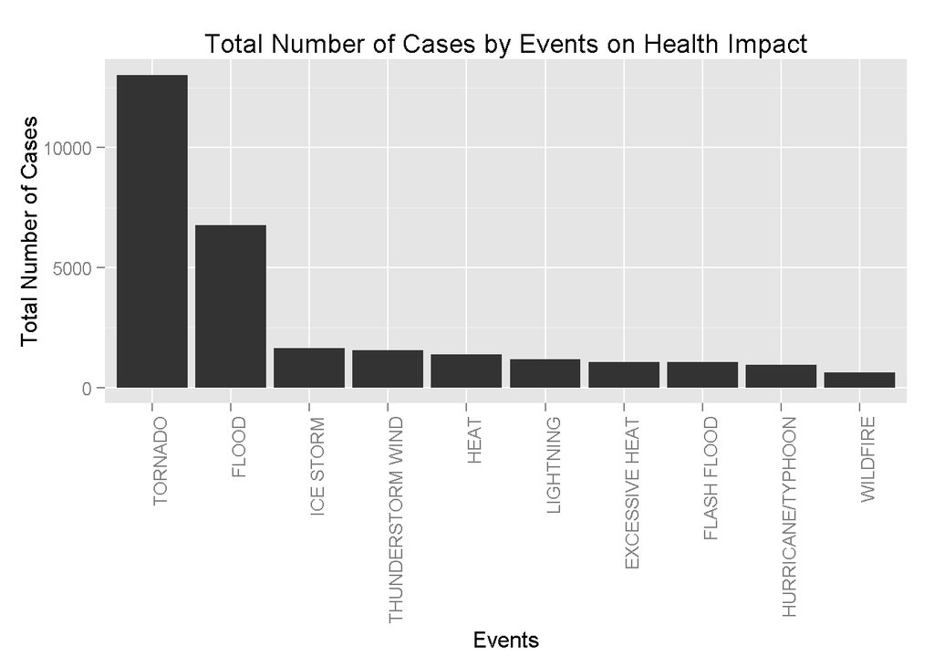

```r
HAZADOUS_EVENTS <- HAZADOUS_EVENTS[with(HAZADOUS_EVENTS, order(-TOTAL_HEALTH_CASE)), ][c(1:10), ];
PLOT <- ggplot(
    HAZADOUS_EVENTS,
    aes(x = reorder(EVTYPE, -TOTAL_HEALTH_CASE), y = TOTAL_HEALTH_CASE)) +
  geom_bar(stat = "identity") +
  xlab("Events") +
  ylab("Total Number of Cases") +
  ggtitle("Total Number of Cases by Events on Health Impact") +
  theme(axis.text.x = element_text(angle = 90, hjust = 1));
print(PLOT);
```

2. Economic Impact

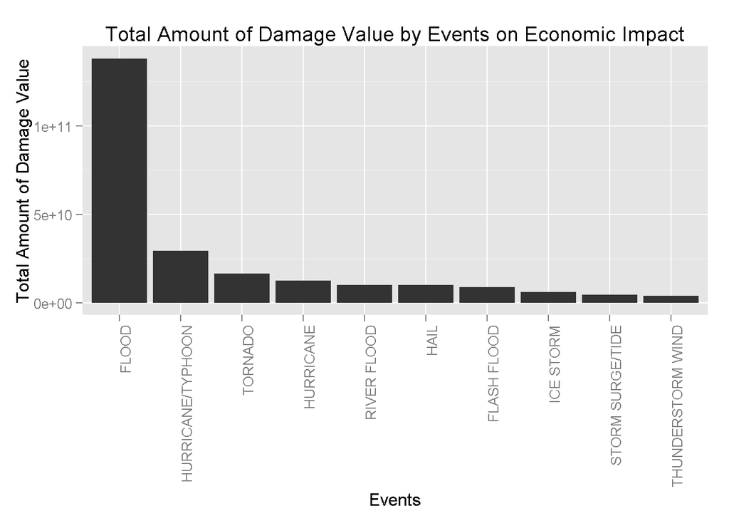

```r
ECONOMIC_IMPACT <- ECONOMIC_IMPACT[with(ECONOMIC_IMPACT, order(-TOTAL_ECONOMIC_DMG_VAL)), ][c(1:10), ];
PLOT <- ggplot(
    ECONOMIC_IMPACT,
    aes(x = reorder(EVTYPE, -TOTAL_ECONOMIC_DMG_VAL), y = TOTAL_ECONOMIC_DMG_VAL)) +
  geom_bar(stat = "identity") +
  xlab("Events") +
  ylab("Total Amount of Damage Value") +
  ggtitle("Total Amount of Damage Value by Events on Economic Impact") +
  theme(axis.text.x = element_text(angle = 90, hjust = 1));
print(PLOT);
```

# Recommendation

Below are the other events that the government of United States should pay attention to on top of the *TORNADO* and *FLOOD* event.

```r
unique(c(as.character(HAZADOUS_EVENTS$EVTYPE), as.character(ECONOMIC_IMPACT$EVTYPE)));
```

```
##  [1] "TORNADO"           "FLOOD"             "ICE STORM"
##  [4] "THUNDERSTORM WIND" "HEAT"              "LIGHTNING"
##  [7] "EXCESSIVE HEAT"    "FLASH FLOOD"       "HURRICANE/TYPHOON"
## [10] "WILDFIRE"          "HURRICANE"         "RIVER FLOOD"
## [13] "HAIL"              "STORM SURGE/TIDE"
```